# Dataset 1: Entity–Relationship Diagram

DATA 607 — Project 3 | Full Job Market and Data Science-Related Jobs

Mohd Afwan Shaikh

2026-10-23

# 1 Purpose

This document describes the relational design produced by **Script 13 (`13_normalize_dataset.R`)** for DATA 607 Project 3. The main research question is:

> Which technical skills are most frequently mentioned across the full job market, and how do skill mentions and advertised salaries compare with Data Science-related jobs?

The full cleaned job-postings dataset is the **primary population**. Data Science-related postings are a separately classified subgroup. Script 13 creates **six core CSV tables and an Excel workbook** under `Data/Normalized/`. The supplied current dataset also includes `job_sector_classification.csv`, giving **seven tables** in the verified CSV snapshot.

The project also has an earlier **five-table PostgreSQL 18 implementation**, based on 226 selected postings. That implementation is documented separately below; running Script 13 does not automatically update the PostgreSQL tables or the existing Graphviz diagram.

# 2 Data acquisition and preparation

The source is the Kaggle *Job Postings with Salaries* dataset by minmaxer. The dataset was downloaded manually as a ZIP archive, extracted, and processed with the project’s R scripts. Scripts 01–12C cover exploration, cleaning, classification, technical-skill extraction, salary analysis, validation, and manual-review decisions. Script 13 (`13_normalize_dataset.R`) creates the normalized CSV exports documented here. This ER document describes the resulting table structure rather than repeating the EDA charts in the main Dataset 1 documentation.

The posting snapshot covers October 2026. The full-market and Data Science subgroup exports must be kept distinct; the exact counts used for the diagram are verified by the R chunks below.

# 3 Source data and scope

- `Data/job_postings_cleaned.csv`: the cleaned source dataset (previously confirmed at 9,173 postings).
- `Data/jobs_skills_analyzed_full.csv`: full-market postings with 30 technical-skill indicators from Script 09.
- `Data/jobs_skills_analyzed.csv`: Data Science-related postings with skill indicators from Script 09.
- `Data/Normalized/`: six core normalized CSV exports and `Dataset1_Normalized_Database.xlsx` from Script 13; the current seventh `job_sector_classification.csv` is a separate supplied export.

The current number of Data Science-related postings is read from the generated file rather than hardcoded, because manual review decisions can change the subset size.

```r
jobs <- read_csv("Data/jobs_skills_analyzed_full.csv", show_col_types = FALSE)
jobs_ds <- read_csv("Data/jobs_skills_analyzed.csv", show_col_types = FALSE)

skill_cols <- setdiff(grep("^skill_", names(jobs), value = TRUE), "skill_count")

stopifnot(
  length(skill_cols) == 30,
  all(skill_cols %in% names(jobs_ds)),
  !anyNA(jobs$job_id),
  anyDuplicated(jobs$job_id) == 0,
  !anyNA(jobs_ds$job_id),
  anyDuplicated(jobs_ds$job_id) == 0,
  all(jobs_ds$job_id %in% jobs$job_id)
)
```

# 4 Data validation

The checks below validate the full-market primary keys, subgroup membership, and technical-skill flags. Skill mentions are detected from job descriptions and are not necessarily formal employer requirements.

```r
validation <- data.frame(
  Check = c(
    "Full-market postings",
    "Unique full-market job IDs",
    "Missing full-market job IDs",
    "Data Science-related postings",
    "Subgroup job IDs absent from full market",
    "Individual skill indicators",
    "Missing full-market skill indicators",
    "Full-market job–skill associations",
    "Subgroup job–skill associations",
    "Full-market postings with no detected skills"
  ),
  Result = c(
    nrow(jobs),
    dplyr::n_distinct(jobs$job_id),
    sum(is.na(jobs$job_id)),
    nrow(jobs_ds),
    sum(!jobs_ds$job_id %in% jobs$job_id),
    length(skill_cols),
    sum(is.na(as.matrix(jobs[skill_cols]))),
    sum(as.matrix(jobs[skill_cols]) == TRUE, na.rm = TRUE),
    sum(as.matrix(jobs_ds[skill_cols]) == TRUE, na.rm = TRUE),
    sum(rowSums(as.matrix(jobs[skill_cols]), na.rm = TRUE) == 0)
  )
)
knitr::kable(validation, caption = "Full-Market and Subgroup Validation")
```

Full-Market and Subgroup Validation

| Check | Result |
| --- | --- |
| Full-market postings | 9173 |
| Unique full-market job IDs | 9173 |
| Missing full-market job IDs | 0 |
| Data Science-related postings | 229 |
| Subgroup job IDs absent from full market | 0 |
| Individual skill indicators | 30 |
| Missing full-market skill indicators | 0 |
| Full-market job–skill associations | 7140 |
| Subgroup job–skill associations | 1142 |
| Full-market postings with no detected skills | 5745 |

The original `skill_count` column is not the same as the 30 Boolean skill indicators and is excluded from the `SKILL` lookup and `JOB_SKILL` junction table. Script 13 builds job–skill associations directly from individual TRUE flags.

# 5 Normalized entities from Script 13

| Entity | Primary key | Key attributes | Purpose |
| --- | --- | --- | --- |
| `COMPANY` | `company_id` | `company_name` | Unique employers, with generated company keys. |
| `JOB_POSTING` | `job_id` | `company_id` (FK), `title`, `posted_at`, `is_data_science_related`, and available job details | All cleaned job postings. |
| `SALARY` | `job_id` (also FK) | Advertised salary fields, eligibility flags, `salary_midpoint_annual` | One salary row per posting, including records without eligible salary values. |
| `SKILL` | `skill_id` | `skill_name`, `source_column` | Lookup of 30 tracked skills. |
| `JOB_SKILL` | (`job_id`, `skill_id`) | Both columns are FKs | One row per detected skill in a job posting. |
| `DATA_SCIENCE_CLASSIFICATION` | `job_id` (also FK) | `job_category_updated`, `classification_updated`, `classification_basis` | Subgroup-specific classifications; only Data Science-related jobs have rows. |
| `JOB_SECTOR_CLASSIFICATION` | `job_id` (also FK) | `sector_name`, `classification_method`, `needs_review` | Sector classification for each full-market posting. |

The current Script 13 derives a generated `company_id` from normalized company names. This is an analytical identifier, not necessarily the original source system’s employer ID.

## 5.1 Keys and relationships

- **COMPANY → JOB_POSTING:** one employer can have many job postings; each posting references one employer.
- **JOB_POSTING → SALARY:** one-to-one in this exported model, using `job_id` as the salary table’s PK and FK. Not all salary rows have valid annual USD amounts.
- **JOB_POSTING → JOB_SKILL:** one-to-many; a posting may have zero detected skills.
- **SKILL → JOB_SKILL:** one-to-many; a skill may occur in zero or many postings.
- **JOB_POSTING → DATA_SCIENCE_CLASSIFICATION:** optional one-to-one; only subgroup postings appear in this table.
- **JOB_POSTING → JOB_SECTOR_CLASSIFICATION:** one-to-one in the supplied CSV snapshot; every posting has a sector classification.

The junction table implements the many-to-many relationship between jobs and skills. Its composite key prevents duplicate job–skill pairs.

## 5.2 Current seven-entity logical diagram (generated from this document)

The following diagram represents the **seven entities** listed above, regardless of whether the saved `.dot` and PNG artwork has been refreshed. It is a logical model of the CSV exports, not proof of a database deployment.

```r
if (requireNamespace("DiagrammeR", quietly = TRUE)) {
  DiagrammeR::grViz(r"(digraph ER {
    graph [rankdir=LR, bgcolor=white, nodesep=0.55, ranksep=0.9]
    node [shape=record, style=filled, fillcolor=aliceblue, color=steelblue4,
          fontname=Helvetica, fontsize=11]
    edge [color=gray35, fontname=Helvetica, fontsize=10]
    COMPANY [label='{COMPANY|PK company_id\lcompany_name\l}']
    JOB_POSTING [label='{JOB_POSTING|PK job_id\lFK company_id\ltitle\lposted_at\lis_data_science_related\l}']
    SALARY [label='{SALARY|PK/FK job_id\lsalary_midpoint_annual\lsalary_usd_eligible\l}']
    SKILL [label='{SKILL|PK skill_id\lskill_name\lsource_column\l}']
    JOB_SKILL [label='{JOB_SKILL|PK/FK job_id\lPK/FK skill_id\l}']
    DATA_SCIENCE_CLASSIFICATION [label='{DATA_SCIENCE_CLASSIFICATION|PK/FK job_id\ljob_category_updated\lclassification_updated\l}']
    JOB_SECTOR_CLASSIFICATION [label='{JOB_SECTOR_CLASSIFICATION|PK/FK job_id\lsector_name\lclassification_method\lneeds_review\l}']
    COMPANY -> JOB_POSTING [label='1 to many']
    JOB_POSTING -> SALARY [label='1 to 1']
    JOB_POSTING -> JOB_SKILL [label='1 to many']
    SKILL -> JOB_SKILL [label='1 to many']
    JOB_POSTING -> DATA_SCIENCE_CLASSIFICATION [label='1 to 0..1']
    JOB_POSTING -> JOB_SECTOR_CLASSIFICATION [label='1 to 1']
  })")
} else {
  cat("Install DiagrammeR to display the seven-entity diagram: install.packages('DiagrammeR')")
}
```

[interactive chart not shown]

# 6 Current normalized export validation

This section reads the actual output tables from Script 13 and checks foreign-key membership. It does not require PostgreSQL access.

```r
# Script 13 produces six core files; the sector file is supplied separately.
# Put all seven CSVs together in Data/Normalized/ or Dashboard_Online/data/.
file_names <- c("COMPANY", "JOB_POSTING", "SALARY", "SKILL",
                "JOB_SKILL", "DATA_SCIENCE_CLASSIFICATION", "JOB_SECTOR_CLASSIFICATION")
locations <- c("Data/Normalized", "Dashboard_Online/data", "data")
find_csv <- function(name) {
  candidates <- unlist(lapply(locations, function(dir) {
    c(file.path(dir, paste0(name, ".csv")),
      file.path(dir, paste0(tolower(name), ".csv")))
  }))
  found <- candidates[file.exists(candidates)]
  if (!length(found)) stop("Missing current CSV for ", name,
                           ". Place all seven exports in Data/Normalized/ or Dashboard_Online/data/.")
  found[1]
}
paths <- vapply(file_names, find_csv, character(1))
tables <- setNames(lapply(paths, readr::read_csv, show_col_types = FALSE), file_names)
knitr::kable(data.frame(table = file_names,
                        rows = vapply(tables, nrow, integer(1))),
             caption = "Current Seven-Table CSV Counts")
```

Current Seven-Table CSV Counts

|  | table | rows |
| --- | --- | --- |
| COMPANY | COMPANY | 3969 |
| JOB_POSTING | JOB_POSTING | 9173 |
| SALARY | SALARY | 9173 |
| SKILL | SKILL | 30 |
| JOB_SKILL | JOB_SKILL | 7140 |
| DATA_SCIENCE_CLASSIFICATION | DATA_SCIENCE_CLASSIFICATION | 229 |
| JOB_SECTOR_CLASSIFICATION | JOB_SECTOR_CLASSIFICATION | 9173 |

```r
stopifnot(
  nrow(tables$COMPANY) == 3969,
  nrow(tables$JOB_POSTING) == 9173,
  nrow(tables$SALARY) == 9173,
  nrow(tables$SKILL) == 30,
  nrow(tables$JOB_SKILL) == 7140,
  nrow(tables$DATA_SCIENCE_CLASSIFICATION) == 229,
  nrow(tables$JOB_SECTOR_CLASSIFICATION) == 9173,
  !anyDuplicated(tables$COMPANY$company_id),
  !anyDuplicated(tables$JOB_POSTING$job_id),
  !anyDuplicated(tables$SALARY$job_id),
  !anyDuplicated(tables$SKILL$skill_id),
  !anyDuplicated(tables$DATA_SCIENCE_CLASSIFICATION$job_id),
  !anyDuplicated(tables$JOB_SECTOR_CLASSIFICATION$job_id),
  !anyDuplicated(tables$JOB_SKILL[c("job_id", "skill_id")]),
  all(tables$JOB_POSTING$company_id %in% tables$COMPANY$company_id),
  all(tables$SALARY$job_id %in% tables$JOB_POSTING$job_id),
  all(tables$JOB_SKILL$job_id %in% tables$JOB_POSTING$job_id),
  all(tables$JOB_SKILL$skill_id %in% tables$SKILL$skill_id),
  all(tables$DATA_SCIENCE_CLASSIFICATION$job_id %in% tables$JOB_POSTING$job_id),
  all(tables$JOB_SECTOR_CLASSIFICATION$job_id %in% tables$JOB_POSTING$job_id)
)
```

# 7 ER diagram: current design and existing artwork

The **current seven-entity model** is generated directly in this report and described in the table and relationships above. The existing `ER_Diagram/Dataset1_ER_Diagram.dot` and PNG may still show the **older five-entity model**. Do not label that artwork as a diagram of the current seven-table export unless its source has been revised to include both classification entities and the full-market scope.

The existing diagram uses dark blue for employers and postings, teal for salary, and purple for skills and their junction table. PK and FK labels indicate keys. Relationship multiplicities are textual Graphviz annotations, not formal crow’s-foot endpoints.

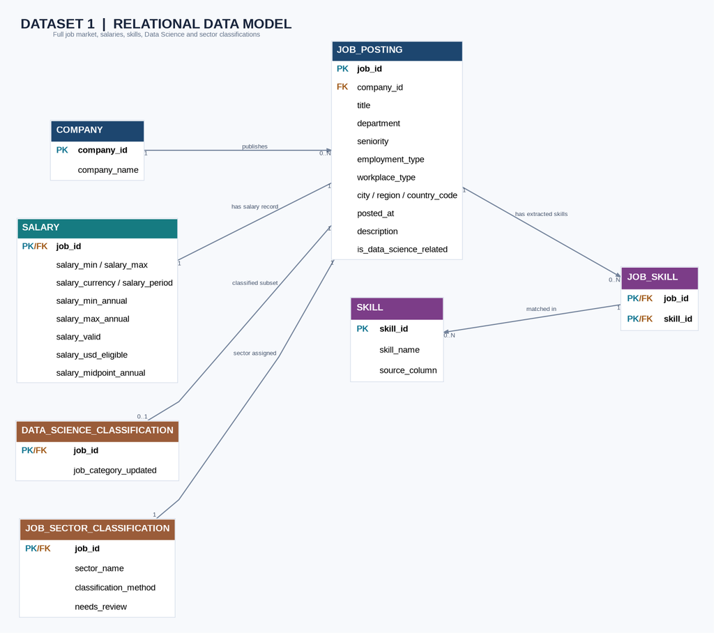

# 8 Render the ER diagram

The existing project includes a Graphviz source at `ER_Diagram/Dataset1_ER_Diagram.dot`. It may be historical. **Use the seven-entity diagram generated above as the current logical model**; rendering the saved file below is only for comparing older artwork.

```r
if (!requireNamespace("DiagrammeR", quietly = TRUE)) {
  stop("Install DiagrammeR with install.packages('DiagrammeR')")
}

source_file <- "ER_Diagram/Dataset1_ER_Diagram.dot"
if (!file.exists(source_file)) {
  stop("Diagram source not found: ", source_file,
       ". Knit from the project root folder.")
}

er_diagram <- DiagrammeR::grViz(
  paste(readLines(source_file, warn = FALSE), collapse = "\n")
)
er_diagram
```

[interactive chart not shown]

The saved-file diagram uses the styling defined in its `.dot` file, which may be historical: color-coded headers, separate key labels, and explicit multiplicity labels. It uses Graphviz arrows and text labels, rather than formal crow’s-foot symbols.

# 9 How the junction table is derived

Each `skill_` column except `skill_count` is a TRUE/FALSE skill indicator. Script 13 converts each TRUE value into one row in `JOB_SKILL`. The current association count is calculated from the full-market dataset, not from the earlier 226-job subset.

```r
match_positions <- which(as.matrix(jobs[skill_cols]) == TRUE, arr.ind = TRUE)

job_skill_preview <- data.frame(
  job_id = jobs$job_id[match_positions[, "row"]],
  skill_name = sub("^skill_", "", skill_cols[match_positions[, "col"]]),
  stringsAsFactors = FALSE
)

stopifnot(nrow(job_skill_preview) == nrow(tables$JOB_SKILL))
head(job_skill_preview, 10)
```

```
##              job_id skill_name
## 1  9c804e62d2c5c251     python
## 2  278f0d851fa3bb28     python
## 3  9c659c248a7f7a11     python
## 4  583c5a06f7ca16bc     python
## 5  abf47298e4c7a72b     python
## 6  8a1a0aec5bb0c7c3     python
## 7  40a95d10ecbd2954     python
## 8  ee91aef7c1862e2a     python
## 9  cd81f8051088e89f     python
## 10 86a0a68b27fab8c6     python
```

The `SKILL` table maps skill names to generated `skill_id` values. `JOB_SKILL` stores the corresponding IDs and references the primary key of `JOB_POSTING`.

# 10 Reproducing and exporting the diagram

The following code recreates the **redesigned** diagram from its `.dot` source and can export a high-resolution PNG after explicit review. The saved `Dataset1_ER_Diagram.R` script performs the same steps. The existing HTML export may display an older design until it is regenerated. Keep the original HTML and PNG intact; the optional example below writes a separate `_Updated.png` file.

```r
library(DiagrammeR)

er_diagram <- grViz(
  paste(readLines("ER_Diagram/Dataset1_ER_Diagram.dot"), collapse = "\n")
)

# Optional PNG export; install DiagrammeRsvg and rsvg if needed.
svg_code <- DiagrammeRsvg::export_svg(er_diagram)
rsvg::rsvg_png(
  charToRaw(svg_code),
  file = "ER_Diagram/Dataset1_ER_Diagram_Updated.png",
  width = 2400
)
```

# 11 Limitations

1. The normalized exports are a logical relational design. They do not, by themselves, prove that the updated schema was imported into PostgreSQL or that SQL foreign-key constraints were created.
2. The saved Graphviz diagram and PostgreSQL SQL scripts may still represent the earlier five-table model and should be updated separately before being presented as the current seven-table implementation.
3. Technical skills are identified from description text; a detected mention does not necessarily imply a required qualification.
4. Salary midpoints are based on advertised ranges. Only valid, eligible annual USD records should be used for salary comparisons.
5. The Data Science-related subgroup is produced through title, responsibility, and manual-review classification, so classification uncertainty remains.
6. A short snapshot of postings cannot establish long-term job market trends.

# 12 Current seven-table CSV dataset (verified October 23, 2026)

The seven CSV files supplied for the current project have the following **verified file row counts**. These counts describe the uploaded exports, not a fresh query against PostgreSQL.

| Table | Uploaded CSV rows | Primary key |
| --- | --- | --- |
| `company` | 3,969 | `company_id` |
| `job_posting` | 9,173 | `job_id` |
| `salary` | 9,173 | `job_id` (PK and FK) |
| `skill` | 30 | `skill_id` |
| `job_skill` | 7,140 | (`job_id`, `skill_id`) |
| `data_science_classification` | 229 | `job_id` (PK and FK) |
| `job_sector_classification` | 9,173 | `job_id` (PK and FK) |

The current CSV set adds `JOB_SECTOR_CLASSIFICATION` to the six core Script 13 exports; the seven-entity model above includes it. Each job can have one sector-classification row; Data Science classification applies only to the selected subgroup. The 229 subgroup rows in the uploaded export must not be confused with the historical 226-job reviewed dataset.

# 13 Previous PostgreSQL implementation (historical)

The earlier `data607_project3` PostgreSQL 18 implementation was verified with five tables, using a selected 226-job subset:

| PostgreSQL table | Previously verified rows | Key |
| --- | --- | --- |
| `company` | 210 | `company_id` |
| `job_posting` | 226 | `job_id` |
| `salary` | 226 | `job_id` (PK and FK) |
| `skill` | 30 | `skill_id` |
| `job_skill` | 1,142 | (`job_id`, `skill_id`) |

These counts describe the **older database state** and must not be presented as the current full-market normalized export counts. Re-running R normalization does not automatically reload PostgreSQL or change its schema. The SQL scripts under `SQL guide/` should be reviewed and updated before a new full-market import.

# 14 Project files

- `13_normalize_dataset.R` — produces six normalized tables from the current full-market and Data Science-related skill datasets.
- `Data/Normalized/` — six core Script 13 CSV files and `Dataset1_Normalized_Database.xlsx`; also place `job_sector_classification.csv` with them for seven-table validation.
- `ER_Diagram/Dataset1_ER_Diagram.dot` — existing Graphviz source; may still describe the older five-table model.
- `ER_Diagram/Dataset1_ER_Diagram.R` — existing diagram rendering script.
- `ER_Diagram/Dataset1_ER_Diagram.png` — existing diagram image; check its entity list before using it as current documentation.
- `SQL guide/Dataset1_Create_Tables.sql` — existing PostgreSQL DDL, which may need updates for the new table and full-market import.

**Knit instructions:** Open this R Markdown file in RStudio with the `DATA607-Project3` project as the working directory, and choose **Knit → Knit to HTML**. The seven current CSV exports must be available together in `Data/Normalized/` or `Dashboard_Online/data/`. The existing Graphviz source and DiagrammeR package are required for the diagram rendering chunk. # References

minmaxer. (n.d.). *Job Postings with Salaries* [Data set]. Kaggle. https://www.kaggle.com/datasets/minmaxer/job-postings-with-salaries